# Data Analyst Portfolio

Ryan Durkin

Updated: July 26, 2025

**[Denver, CO] | [858-349-4783] | [durkinrm@gmail.com] | [https://www.linkedin.com/in/ryan-durkin-1b93aaa2/] | [https://github.com/Phrease]**

### **Summary**

A highly motivated and detail-oriented data analyst with a passion for uncovering insights from data. Proficient in R for data manipulation, statistical analysis, and visualization. Seeking to leverage my analytical skills to solve complex problems and contribute to a data-driven organization.

### **Skills**

- **Programming Languages:** R (Advanced), SQL (Advanced), Python (Intermediate)
- **R Libraries:** `dplyr`, `ggplot2`, `tidyr`, `readr`, `shiny`, `rmarkdown`, `lubridate`
- **Data Visualization:** ggplot2, Tableau, Power BI
- **Databases:** PostgreSQL, MySQL, SQLite
- **Tools:** RStudio, Git & GitHub, Jupyter Notebooks

## **Project Showcase**

### **Project 1: Analyzing Colorado Counties via Rent Burden & Median Household Income**

```
##     median_gross_rent   median_house_income total_renter_occupied
##          "B25064_001"          "B19013_001"          "B25070_001"
##        rent_lt_10_pct      rent_10_14_9_pct      rent_15_19_9_pct
##          "B25070_002"          "B25070_003"          "B25070_004"
##      rent_20_24_9_pct      rent_25_29_9_pct      rent_30_34_9_pct
##          "B25070_005"          "B25070_006"          "B25070_007"
##      rent_35_39_9_pct      rent_40_49_9_pct      rent_50_plus_pct
##          "B25070_008"          "B25070_009"          "B25070_010"
##     rent_not_computed
##          "B25070_011"
```

[output not shown]

```
## Simple feature collection with 6 features and 5 fields
## Geometry type: MULTIPOLYGON
## Dimension:     XY
## Bounding box:  xmin: -109.0603 ymin: 38.49999 xmax: -107.3775 ymax: 39.36671
## Geodetic CRS:  NAD83
##   GEOID                  NAME              variable estimate  moe
## 1 08077 Mesa County, Colorado   median_house_income    68077 2075
## 2 08077 Mesa County, Colorado     median_gross_rent     1089   47
## 3 08077 Mesa County, Colorado total_renter_occupied    17781  884
## 4 08077 Mesa County, Colorado        rent_lt_10_pct     1027  351
## 5 08077 Mesa County, Colorado      rent_10_14_9_pct     1681  421
## 6 08077 Mesa County, Colorado      rent_15_19_9_pct     1943  382
##                         geometry
## 1 MULTIPOLYGON (((-109.0603 3...
## 2 MULTIPOLYGON (((-109.0603 3...
## 3 MULTIPOLYGON (((-109.0603 3...
## 4 MULTIPOLYGON (((-109.0603 3...
## 5 MULTIPOLYGON (((-109.0603 3...
## 6 MULTIPOLYGON (((-109.0603 3...
```

```
## Rows: 832
## Columns: 6
## $ GEOID    <chr> "08077", "08077", "08077", "08077", "08077", "08077", "08077"…
## $ NAME     <chr> "Mesa County, Colorado", "Mesa County, Colorado", "Mesa Count…
## $ variable <chr> "median_house_income", "median_gross_rent", "total_renter_occ…
## $ estimate <dbl> 68077, 1089, 17781, 1027, 1681, 1943, 1948, 2072, 1079, 1233,…
## $ moe      <dbl> 2075, 47, 884, 351, 421, 382, 352, 442, 273, 304, 260, 487, 3…
## $ geometry <MULTIPOLYGON [°]> MULTIPOLYGON (((-109.0603 3..., MULTIPOLYGON (((…
## Simple feature collection with 832 features and 5 fields
## Geometry type: MULTIPOLYGON
## Dimension:     XY
## Bounding box:  xmin: -109.0603 ymin: 36.99243 xmax: -102.0415 ymax: 41.00344
## Geodetic CRS:  NAD83
## First 10 features:
##    GEOID                  NAME              variable estimate  moe
```

[output cut: 21 more lines]

```
## Simple feature collection with 6 features and 32 fields
## Geometry type: MULTIPOLYGON
## Dimension:     XY
## Bounding box:  xmin: -109.0603 ymin: 36.99891 xmax: -104.3511 ymax: 39.91418
## Geodetic CRS:  NAD83
## # A tibble: 6 × 33
##   GEOID NAME                      geometry median_house_income median_gross_rent
##   <chr> <chr>           <MULTIPOLYGON [°]>               <dbl>             <dbl>
## 1 08077 Mesa Co… (((-109.0603 38.59933, -…               68077              1089
## 2 08083 Montezu… (((-109.0459 37.32686, -…               61377               893
## 3 08067 La Plat… (((-108.3796 37.00418, -…               81936              1344
## 4 08031 Denver … (((-104.9341 39.70018, -…               85853              1665
## 5 08019 Clear C… (((-105.927 39.6767, -10…               87169              1201
## 6 08055 Huerfan… (((-105.5013 37.5986, -1…               49631               735
## # ℹ 28 more variables: total_renter_occupied <dbl>, rent_lt_10_pct <dbl>,
## #   rent_10_14_9_pct <dbl>, rent_15_19_9_pct <dbl>, rent_20_24_9_pct <dbl>,
## #   rent_25_29_9_pct <dbl>, rent_30_34_9_pct <dbl>, rent_35_39_9_pct <dbl>,
## #   rent_40_49_9_pct <dbl>, rent_50_plus_pct <dbl>, rent_not_computed <dbl>,
## #   moe_median_house_income <dbl>, moe_median_gross_rent <dbl>,
## #   moe_total_renter_occupied <dbl>, moe_rent_lt_10_pct <dbl>,
## #   moe_rent_10_14_9_pct <dbl>, moe_rent_15_19_9_pct <dbl>, …
```

```
## Rows: 64
## Columns: 33
## $ GEOID                     <chr> "08077", "08083", "08067", "08031", "08019",…
## $ NAME                      <chr> "Mesa County, Colorado", "Montezuma County, …
## $ geometry                  <MULTIPOLYGON [°]> MULTIPOLYGON (((-109.0603 3...,…
## $ median_house_income       <dbl> 68077, 61377, 81936, 85853, 87169, 49631, 78…
## $ median_gross_rent         <dbl> 1089, 893, 1344, 1665, 1201, 735, 1239, 1330…
## $ total_renter_occupied     <dbl> 17781, 2784, 6655, 163481, 917, 646, 571, 27…
## $ rent_lt_10_pct            <dbl> 1027, 99, 331, 5117, 17, 30, 46, 194, 32, 5,…
## $ rent_10_14_9_pct          <dbl> 1681, 301, 597, 12299, 98, 43, 78, 308, 57, …
## $ rent_15_19_9_pct          <dbl> 1943, 218, 588, 21785, 119, 47, 66, 199, 36,…
## $ rent_20_24_9_pct          <dbl> 1948, 213, 705, 23321, 31, 88, 21, 137, 17, …
## $ rent_25_29_9_pct          <dbl> 2072, 258, 708, 21675, 57, 0, 87, 434, 53, 3…
## $ rent_30_34_9_pct          <dbl> 1079, 371, 667, 14746, 237, 17, 3, 272, 146,…
## $ rent_35_39_9_pct          <dbl> 1233, 175, 347, 10093, 81, 51, 0, 99, 29, 7,…
```

[output cut: 45 more lines]

```
##  [1] "GEOID"                     "NAME"
##  [3] "geometry"                  "median_house_income"
##  [5] "median_gross_rent"         "total_renter_occupied"
##  [7] "rent_lt_10_pct"            "rent_10_14_9_pct"
##  [9] "rent_15_19_9_pct"          "rent_20_24_9_pct"
## [11] "rent_25_29_9_pct"          "rent_30_34_9_pct"
## [13] "rent_35_39_9_pct"          "rent_40_49_9_pct"
## [15] "rent_50_plus_pct"          "rent_not_computed"
## [17] "moe_median_house_income"   "moe_median_gross_rent"
## [19] "moe_total_renter_occupied" "moe_rent_lt_10_pct"
## [21] "moe_rent_10_14_9_pct"      "moe_rent_15_19_9_pct"
## [23] "moe_rent_20_24_9_pct"      "moe_rent_25_29_9_pct"
## [25] "moe_rent_30_34_9_pct"      "moe_rent_35_39_9_pct"
## [27] "moe_rent_40_49_9_pct"      "moe_rent_50_plus_pct"
## [29] "moe_rent_not_computed"     "computable_renters_total"
## [31] "pct_rent_50_plus"          "pct_rent_30_plus"
## [33] "pct_rent_35_plus"
```

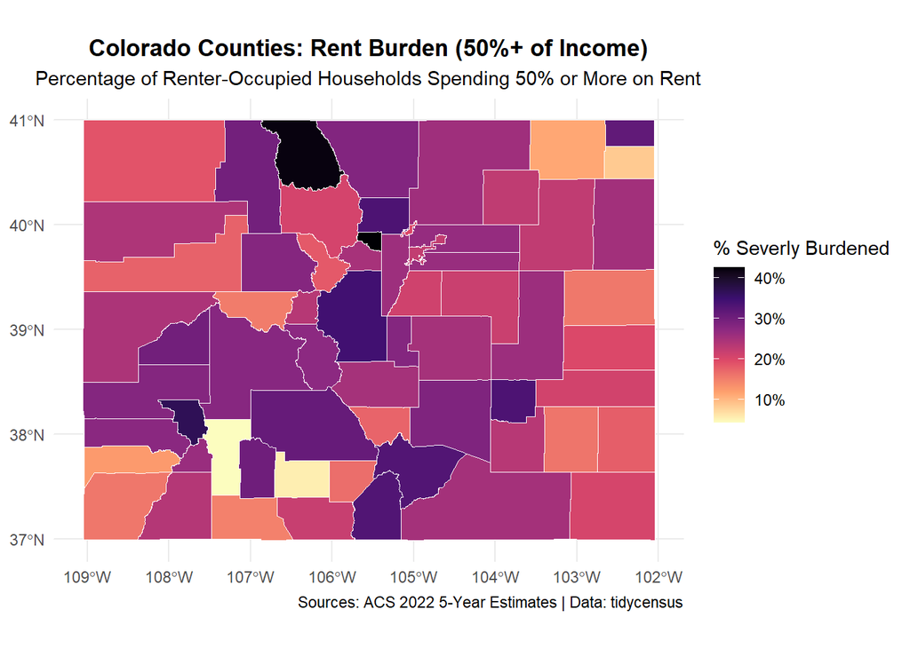

Coloardo Counties Rent Burden compared to Median Household Income

[output not shown]

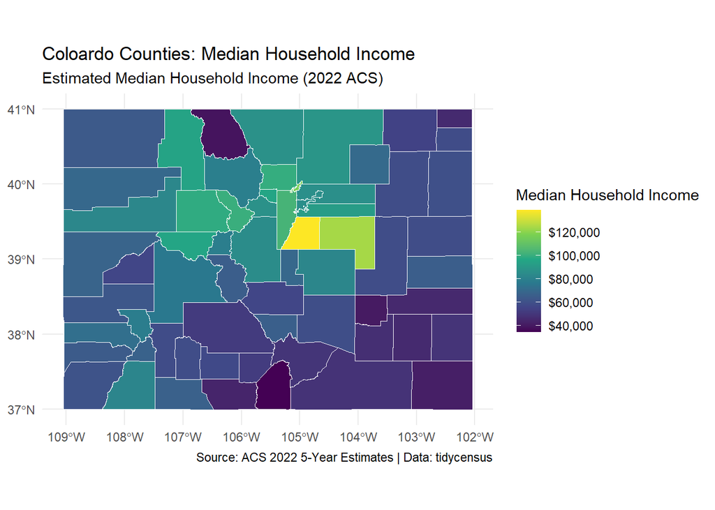

Coloardo Counties Rent Burden compared to Median Household Income

[output not shown]

### **Project 2: Analyzing Colorado Tornadoes**

- **Objective:** To analyze historical storm data to identify trends in tornado frequency, intensity, and location within Colorado over the past five years.
- **Description:** This project used a dataset from the NOAA Storm Events Database. The data was cleaned and processed using dplyr and lubridate. Analysis focused on annual and monthly trends, intensity distributions (F/EF Scale), and geographic hotspots by county. The final report includes several visualizations from ggplot2 that highlight key findings.
- **Key Skills Demonstrated:** Data Cleaning, Data Wrangling, Time-Series Analysis, Geospatial Visualization, R Markdown.
- **Code:** [Link to GitHub Repository for this Project](https://github.com/Phrease/R-Portfolio-Project/tree/main/analyses/colorado%20weather%20patterns%20analysis)

```
## here() starts at C:/Users/durki/OneDrive/Desktop/R-Portfolio-Project
```

```
## # A tibble: 6 × 39
##   EVENT_ID CZ_NAME_STR BEGIN_LOCATION BEGIN_DATE BEGIN_TIME EVENT_TYPE MAGNITUDE
##      <dbl> <chr>       <chr>          <chr>           <dbl> <chr>      <lgl>
## 1   897582 OTERO CO.   CHERAW         05/19/2020       1915 Tornado    NA
## 2   890142 WELD CO.    GREELEY ARPT   05/20/2020       1738 Tornado    NA
## 3   890143 WELD CO.    EATON ARPT     05/20/2020       1741 Tornado    NA
## 4   890145 WELD CO.    GREELEY ARPT   05/20/2020       1745 Tornado    NA
## 5   890148 WELD CO.    GREELEY ARPT   05/20/2020       1746 Tornado    NA
## 6   890163 WELD CO.    GREELEY ARPT   05/20/2020       1756 Tornado    NA
## # ℹ 32 more variables: TOR_F_SCALE <chr>, DEATHS_DIRECT <dbl>,
## #   INJURIES_DIRECT <dbl>, DAMAGE_PROPERTY_NUM <dbl>, DAMAGE_CROPS_NUM <dbl>,
## #   STATE_ABBR <chr>, CZ_TIMEZONE <chr>, MAGNITUDE_TYPE <lgl>,
## #   EPISODE_ID <dbl>, CZ_TYPE <chr>, CZ_FIPS <dbl>, WFO <chr>,
## #   INJURIES_INDIRECT <dbl>, DEATHS_INDIRECT <dbl>, SOURCE <chr>,
## #   FLOOD_CAUSE <lgl>, TOR_LENGTH <dbl>, TOR_WIDTH <dbl>, BEGIN_RANGE <dbl>,
## #   BEGIN_AZIMUTH <chr>, END_RANGE <dbl>, END_AZIMUTH <chr>, …
```

[output not shown]

[output cut: 29 more lines]

[output not shown]

```
##     EVENT_ID       CZ_NAME_STR        BEGIN_LOCATION      BEGIN_DATE
##  Min.   : 890142   Length:225         Length:225         Length:225
##  1st Qu.: 956808   Class :character   Class :character   Class :character
##  Median :1044576   Mode  :character   Mode  :character   Mode  :character
##  Mean   :1043052
##  3rd Qu.:1108823
##  Max.   :1212705
##    BEGIN_TIME    EVENT_TYPE        MAGNITUDE      TOR_F_SCALE
##  Min.   : 800   Length:225         Mode:logical   Length:225
##  1st Qu.:1424   Class :character   NA's:225       Class :character
##  Median :1543   Mode  :character                  Mode  :character
##  Mean   :1541
##  3rd Qu.:1659
##  Max.   :2027
##  DEATHS_DIRECT INJURIES_DIRECT DAMAGE_PROPERTY_NUM DAMAGE_CROPS_NUM
##  Min.   :0     Min.   :0       Min.   :      0     Min.   :0
##  1st Qu.:0     1st Qu.:0       1st Qu.:      0     1st Qu.:0
##  Median :0     Median :0       Median :      0     Median :0
##  Mean   :0     Mean   :0       Mean   :   9336     Mean   :0
##  3rd Qu.:0     3rd Qu.:0       3rd Qu.:      0     3rd Qu.:0
##  Max.   :0     Max.   :0       Max.   :1000000     Max.   :0
##   STATE_ABBR        CZ_TIMEZONE        MAGNITUDE_TYPE   EPISODE_ID
##  Length:225         Length:225         Mode:logical   Min.   :147178
##  Class :character   Class :character   NA's:225       1st Qu.:158058
##  Mode  :character   Mode  :character                  Median :172044
##                                                       Mean   :171194
##                                                       3rd Qu.:181814
##                                                       Max.   :196030
##    CZ_TYPE             CZ_FIPS           WFO            INJURIES_INDIRECT
##  Length:225         Min.   :  1.00   Length:225         Min.   :0
##  Class :character   1st Qu.: 63.00   Class :character   1st Qu.:0
##  Mode  :character   Median : 93.00   Mode  :character   Median :0
##                     Mean   : 82.86                      Mean   :0
##                     3rd Qu.:121.00                      3rd Qu.:0
##                     Max.   :125.00                      Max.   :0
##  DEATHS_INDIRECT    SOURCE          FLOOD_CAUSE      TOR_LENGTH
##  Min.   :0       Length:225         Mode:logical   Min.   : 0.010
##  1st Qu.:0       Class :character   NA's:225       1st Qu.: 0.010
##  Median :0       Mode  :character                  Median : 0.490
##  Mean   :0                                         Mean   : 1.442
```

[output cut: 15 more lines]

```
##                                                           Max.   :2035
##    BEGIN_LAT       BEGIN_LON         END_LAT         END_LON
##  Min.   :37.03   Min.   :-107.1   Min.   :37.01   Min.   :-107.1
##  1st Qu.:38.95   1st Qu.:-103.7   1st Qu.:38.96   1st Qu.:-103.7
##  Median :39.90   Median :-103.2   Median :39.90   Median :-103.2
##  Mean   :39.56   Mean   :-103.4   Mean   :39.56   Mean   :-103.3
##  3rd Qu.:40.14   3rd Qu.:-102.8   3rd Qu.:40.13   3rd Qu.:-102.8
##  Max.   :40.96   Max.   :-102.0   Max.   :40.96   Max.   :-102.1
##  EVENT_NARRATIVE    EPISODE_NARRATIVE  ABSOLUTE_ROWNUMBER
##  Length:225         Length:225         Min.   :  1
##  Class :character   Class :character   1st Qu.: 57
##  Mode  :character   Mode  :character   Median :113
##                                        Mean   :113
##                                        3rd Qu.:169
##                                        Max.   :225
```

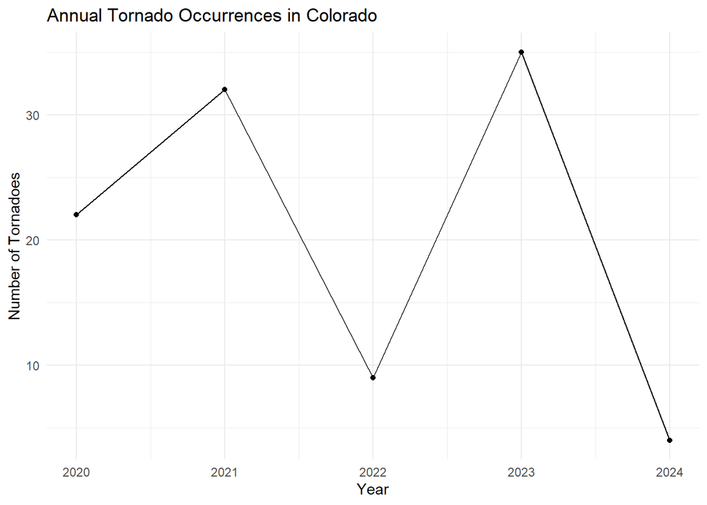

Analyizing Tornado Activity in Colorado in the Past 5 Year

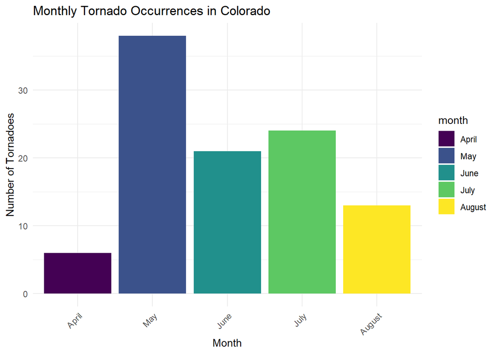

Analyizing Tornado Activity in Colorado in the Past 5 Year

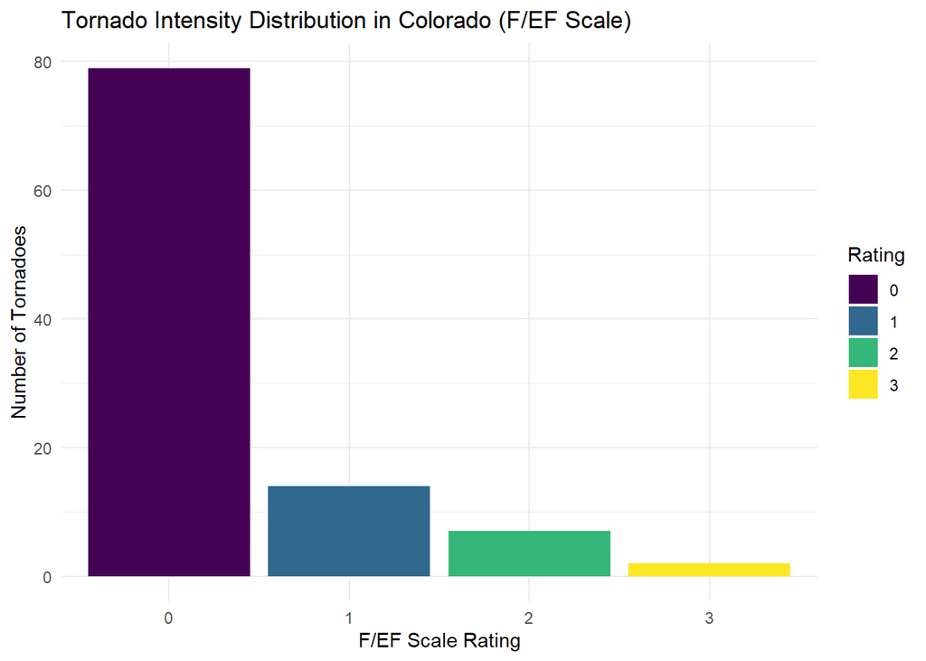

Analyizing Tornado Activity in Colorado in the Past 5 Year

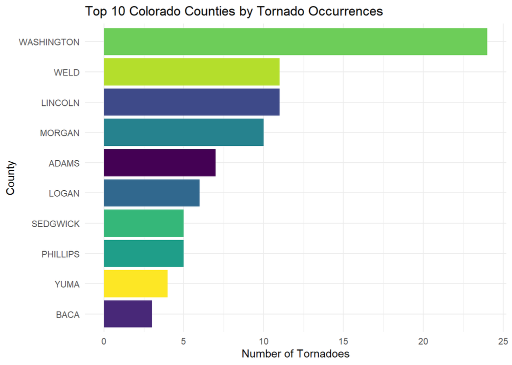

Analyizing Tornado Activity in Colorado in the Past 5 Year

```
## # A tibble: 4 × 4
##   f_scale_numeric total_injuries total_fatalities total_property_damage_billions
##             <dbl>          <dbl>            <dbl>                          <dbl>
## 1               0              0                0                       0.000005
## 2               1              0                0                       0.00052
## 3               2              0                0                       0.000576
## 4               3              0                0                       0.001
```

[figure not shown]

Analyizing Tornado Activity in Colorado in the Past 5 Year

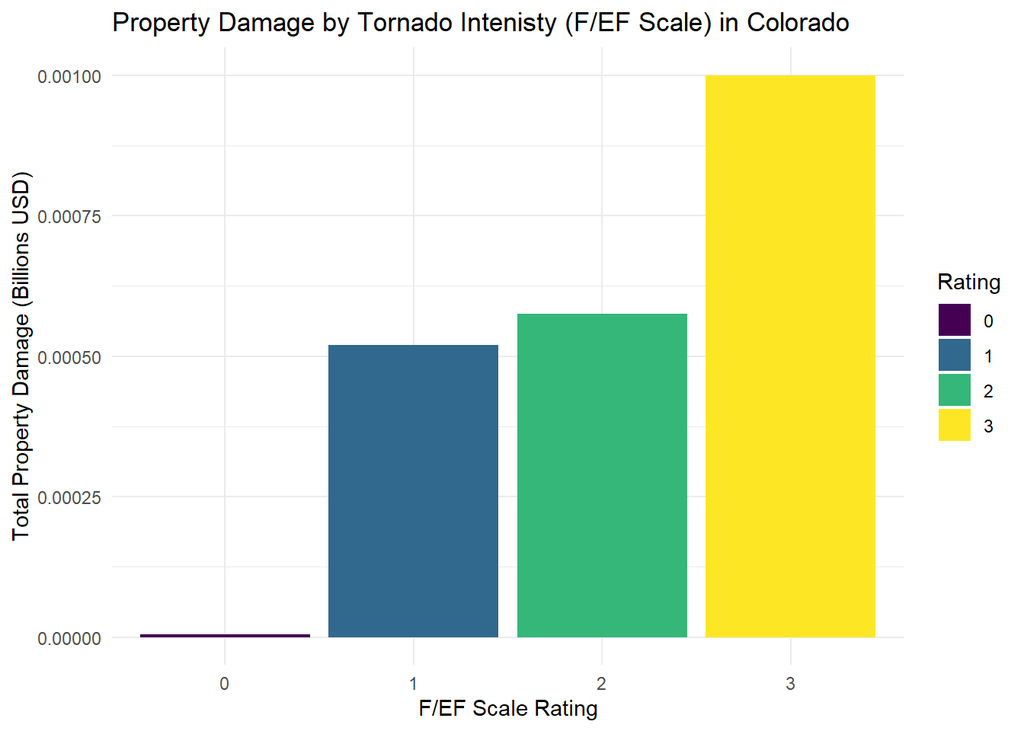

Analyizing Tornado Activity in Colorado in the Past 5 Year

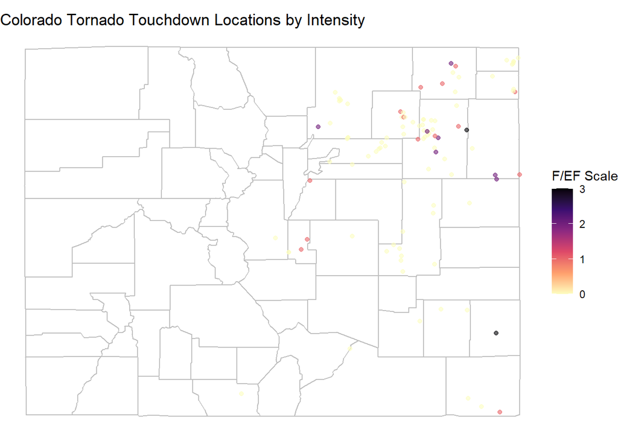

Analyizing Tornado Activity in Colorado in the Past 5 Year

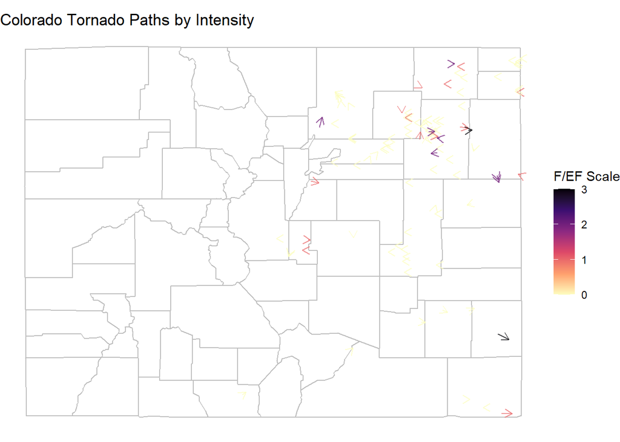

Analyizing Tornado Activity in Colorado in the Past 5 Year

### **Project 3: Analyzing Asteroid Densities by their Weighted Mean**

- **Objective: To calculate a more accurate central tendency for asteroid densities by applying a weighted mean that accounts for measurement uncertainty.
- **Description: This analysis uses the asteroid_dens dataset from the astrodatR package. Instead of a simple average, a weighted mean was calculated, giving more influence to measurements with lower uncertainty (i.e., higher precision). This provides a more robust estimate of the true average density of the asteroid population in the sample.
- **Key Skills Demonstrated:** Statistical Analysis, Weighted Means, Data Visualization, R Markdown Reporting.
- **Code:** [Link to GitHub Repository for this Project](https://github.com/Phrease/R-Portfolio-Project/tree/main/analyses/asteroid%20density%20analysis)

```
## --- Basic Statistics ---
```

```
## Simple Mean Density: 2.182 g/cm^3
```

```
## Median Density: 2.06 g/cm^3
```

```
## Standard Deviation of Densities: 1.047 g/cm^3
```

```
## Weighted Mean Density (accounting for uncertainty): 2.336 g/cm^r
```

```
## Standard Error of the Weighted Mean: 0.021 g/cm^r
```

```
##
## --- Precision Analysis ---
```

```
## Top 5 Most Precisely Measure Asteroids:
```

```
##           name density  unc
## 1     433_Eros    2.67 0.03
## 2      1_Ceres    2.12 0.04
## 3 4492_Debussy    0.90 0.10
## 4     2_Pallas    2.71 0.11
## 5      4_Vesta    3.44 0.12
```

```
## Top 5 Least Precisely Measure Asteroids:
```

```
##              name density  unc
## 22      2000_UG11    1.47 0.95
## 23     2000_DP107    1.62 1.05
## 24      10_Hygiea    2.76 1.20
## 25 704_Interamnia    4.40 2.10
## 26   804_Hispania    4.90 3.90
```

[figure not shown]

Asteroid Density Measured by Weighted Mean

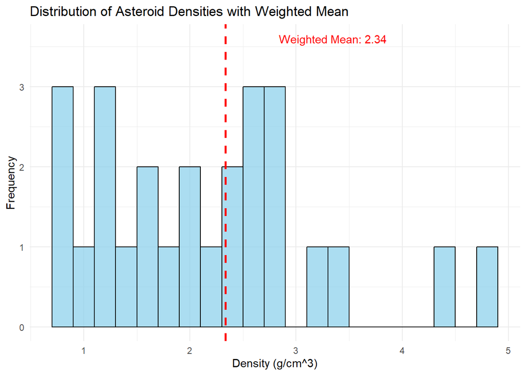

Asteroid Density Measured by Weighted Mean

```
##
## --- Asteroids with Largest Deviations (in terms of their uncertainty) ---
```

```
##            name density  unc   w_mean deviation_in_unc
## 1  4492_Debussy    0.90 0.10 2.336228        14.362279
## 2      433_Eros    2.67 0.03 2.336228        11.125737
## 3   854_Frostia    0.89 0.13 2.336228        11.124830
## 4 617_Patroclus    0.80 0.15 2.336228        10.241519
## 5       4_Vesta    3.44 0.12 2.336228         9.198101
```